# uwa6xv_M02_HW

# Problem 2

Import stateCovid.csv. If extra column, remove.

```r
stateCovid<-read.csv("stateCovid.csv")
stateCovid<-stateCovid[,-c(1)]
```

**(a)**  
Merge these two datasets, stateCovid.csv and State_pop_election.csv. Use the head() function to display the first 6 rows after merging these two datasets.

```r
election<-read.csv("State_pop_election.csv")
# remove non-matching rows: Guam, Virgin Islands, Northern Marina Islands
stateCovid2<-stateCovid[-c(12,37,50),]
electionCovid<-data.frame(election,stateCovid2)
electionCovid<-electionCovid[,-c(4)]
head(electionCovid)
```

```
##        State Population Election   cases deaths state.rate
## 1    Alabama    5024279    Trump  545028  11188       2.05
## 2     Alaska     733391    Trump   69826    352       0.50
## 3    Arizona    7151502    Biden  882691  17653       2.00
## 4   Arkansas    3011524    Trump  341889   5842       1.71
## 5 California   39538223    Biden 3793055  63345       1.67
## 6   Colorado    5773714    Biden  547961   6746       1.23
```

**(b)**  
Pick at least two variables from the dataset and create a suitable visualization of the variables. Comment on what the visualization reveals. You may create new variables based on existing variables, and decribe how you created the new variables. 2

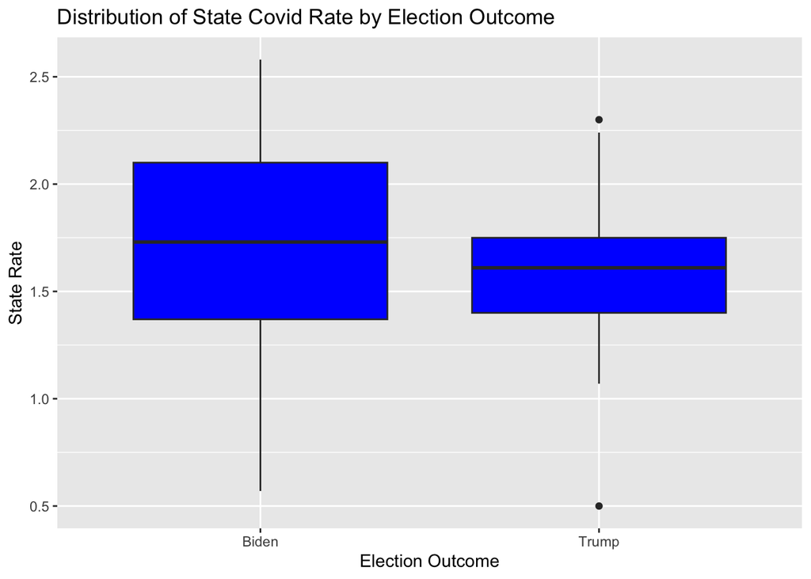

```r
# I want to see the proportion of covid deaths (state rate) compared to election outcome (Trump or Biden).
electionCovid_nomiss<-na.omit(electionCovid)
ggplot(electionCovid_nomiss,aes(x=Election, y=state.rate))+
  geom_boxplot(fill="Blue")+
  labs(x="Election Outcome", y="State Rate", title="Distribution of State Covid Rate by Election Outcome")
```

For the states that had elected Biden in 2020 there is a wider distribution of state rates of Covid, particularly from the 25th to 75th percentile. State rates is defined as the percent of covid deaths per covid cases for each state. The median of the states that elected Biden is slightly higher than the median of the states that elected Trump.